# Comp 112 Lecture 1 Course Introduction

2017.09.05

# About the Course

## Course Topic

Introduction to **imperative programming**, using the programming language **Python**.

## Course Objectives

- Learn to write, read and reason about simple programs.
- Use programming to solve interesting problems:
  - Decompose complex problems into simpler subproblems,
  - solve each subproblem,
  - and combine the solutions to solve the original problem.

## Course Audience

Is this course for you?

- background
  - comfortable using computers

    (running programs, opening/saving files, editing text)
  - little or no programming experience
- intended plans
  - want to use programing in the laboratory/social sciences, humanities, arts etc.
- alternatives:
  - COMP 211

    more rigorous/mathematical, more complex assignments/projects
  - QAC 155

    Python programming for data management
  - ITS mini courses

    tutorials for using specific software applications

## Course Components

**Lecture**

weekly (Tuesdays, 8:50AM, Exley 121)

**Lab**

weekly (time/place varies by section)

**Reading**

free online book: [*Think Python* (2nd ed.)](http://greenteapress.com/wp/think-python-2e/). Readings assigned weekly.

**Homework**

weekly (released to [Moodle](http://moodle.wesleyan.edu/) shortly after each lecture, due by beginning of following lecture)

**Exam**

two midterms (on October 26 and December 5)

**Programming Project**

in lieu of final exam at end of semester (details to follow)

## Course Resources

**Lab**

instructor and C.A.s

**Drop-In Help Clinic**

run by C.A.s on Sun., Mon. and Thurs. evenings 7:00-9:00 in Exley 103

**Office Hours**

scheduled and by appointment

# About Imperative Programming

## What do Computers do?

(discussion)

## What is an Algorithm?

(discussion)

## How can we Communicate an Algorithm to a Computer?

(discussion)

## Programming Languages

A **programming language** is a *formal language* for representing and manipulating information and performing tasks.

An **imperative** programming language does this using sequences of instructions. (Do this, next do that…)

## Why Learn to Program?

- Interact with computers on your own terms.
- Automate laborious tasks.
- Bring your ideas to life.
- Gain a mental force multiplier.
- It’s fun!

## How to Learn Programming

- Learn **what** – i.e. concepts (lecture, readings)
- Learn **how** – i.e. skills (lab, homework)

Learning programming is a process,

to be successful, you need to invest time and attention.

## Why Might Programming Seem Hard?

- High level of precision and detail required.
- Unfamiliar syntax.

## Syntax and Parsing

- **Syntax** is the rules for expressing an idea in a particular language.
- Example: English has rules for *spelling*, *punctuation* and *grammar*.
- To be understood, we must *express* our thoughts according to the rules. (…sorta)
- Extracting the idea from the representation is **parsing**.

*Natural languages* tend to be complex and flexible:

To die, to sleep; to sleep, perchance to dream; aye, there’s the rub, for in that sleep of death, what dreams may come, when we have shuffled off this mortal coil, must give us pause.

*Formal languages* are typically simple but rigid:

```python
for x in xs :
    acc += len (x)
```

## Example: Parsing Arithmetic

```
3 + 4 × 5
```

means

```
3 + (4 × 5)
```

or

[figure not shown]

Note: although “$3 + (4 × 5)$” and “$(5 × 4) + 3$” have the same **value**, they are not the same **expression**!

## Algorithms

Named for Al-Khwārizmī, a 9th c. Persian mathematician, astronomer and cartographer.

**Algorithm**

a complete description of a procedure for accomplishing some task.

- must be clear and unambiguous
- no ingenuity or creativity required
- must eventually produce a result

Programming languages let us communicate algorithms to computers.

Upshot: the computers can do the work of carrying them out!

Historical note: a “computer” used to be a person.

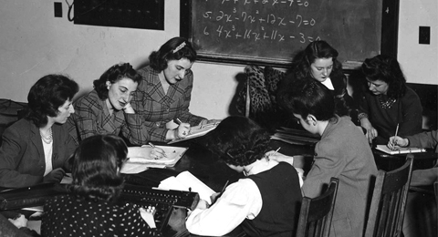

## Example: Evaluating Arithmetic

```
3 + (4 × 5)
```

steps to

```
3 + 20
```

steps to

```
23
```

or

[figure not shown]

# About Python

## Python

**Python** is:

- a popular high-level imperative programming language,
- a collection of software tools to manipulate and run programs written in that language.

In this course we will use the Python language version 3.

## Python, the Language

**popular**

lots of users, platforms, libraries and tools

**high-level**

details of the underlying hardware, operating system, etc. are abstracted away

## Python, the Platform

- An *open-source* project (http://python.org)
- An *interpreter* (`python`, `python3`)
- A program editor (`IDLE`)
- Documentation (books, videos, reference manuals, etc.)
- Community (mailing lists, blogs, conferences, etc.)

## To Do This Week:

- Download the book [*Think Python* (2nd ed.)](http://greenteapress.com/wp/think-python-2e/) and read chapter 1 (8 pages).
- Come to lab on Thursday. (Bring a pair of headphones if you have one handy.)
- Complete homework 1.
- Follow instructions to download and install [Python3](https://python.org/) for your computer (if you don’t already have it installed).